# Indel Signature InsDel13

# InsDel13

**Note**

In the 89-type classification, InsDel_C looks somewhat similar to InsDel13 in the prominence of deletions of Ts that are followed by A. However, the 83-type and 476-type classifications show that InsDel13 has deletions of from TT to T (e.g. ATTA -> ATA), while InsDel_C has deletions of single isolated Ts (e.g. ATA -> AA).

Nevertheless, InsDel13 and InsDel_C were extracted separately in the 89-type classification, possibly because of the insertion of isolated Ts in InsDel13 but not InsDel_C.

(corresponds to 83-type signature C_ID13)

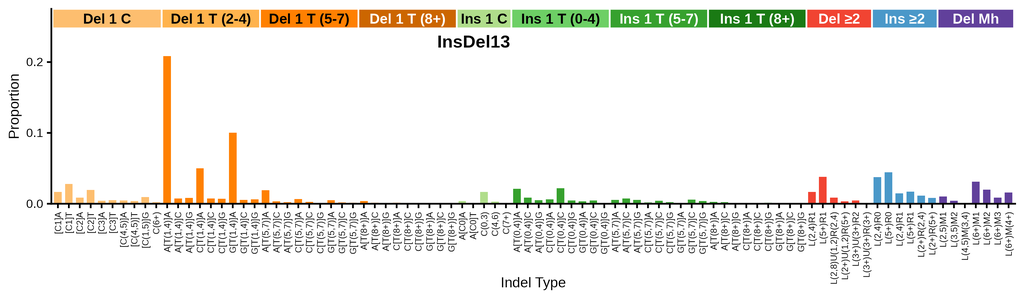

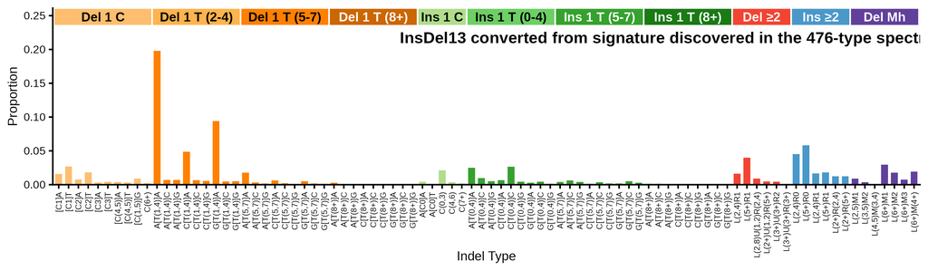

89-type spectrum of the linking tumor CPCT02060291T | cosine similarity to InsDel13: 0.9908

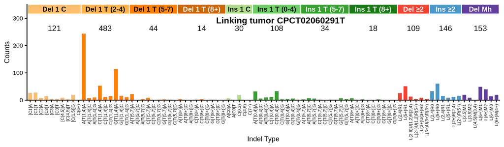

**Click to view decomposition of the linking tumor spectrum**

Partial mutation signature of CPCT02060291T due to InsDel13

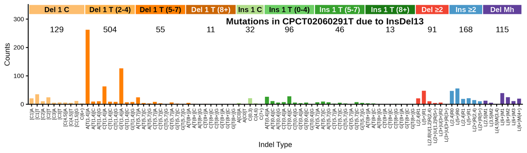

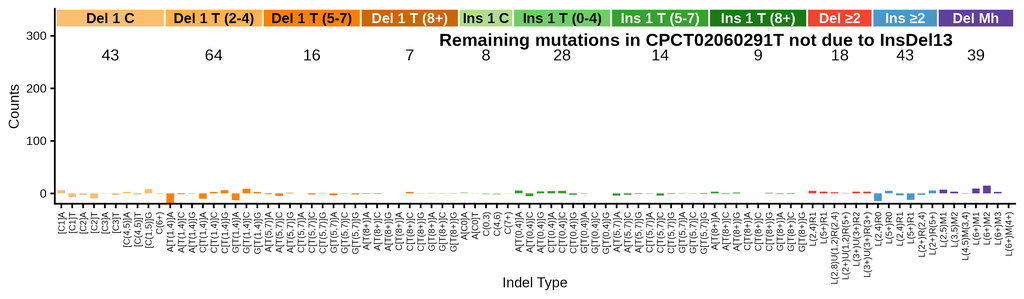

Max neg fraction (maximum allowed negative residual count as fraction of total): 0.15  
N subtract (mutation count assigned to signature): 1260.0  
N residual (mutation count in residual “partial spectrum”): 0.0  
Total negative (sum of negative residual mutation counts): 145.0  
N negative channels (number of channels with negative residual): 45  
P(≥ total negative) (Monte Carlo estimated probability that negative-binomial-sampled spectra from the signature contributing N subtract mutations would produce a total negative count >= the observed Total negative; higher number means not surprising): 0.812

**Per-channel residual breakdown**

| Channel | Spectrum | Sig_Count | Residual | Sig_Prop |
| --- | --- | --- | --- | --- |
| [Del(C):R1]A | 27 | 20.9 | 6.1 | 0.01660 |
| [Del(C):R1]T | 28 | 35.1 | -7.1 | 0.02782 |
| [Del(C):R2]A | 8 | 10.6 | -2.6 | 0.00845 |
| [Del(C):R2]T | 15 | 24.5 | -9.5 | 0.01948 |
| [Del(C):R3]A | 5 | 5.4 | -0.4 | 0.00431 |
| [Del(C):R3]T | 4 | 6.3 | -2.3 | 0.00503 |
| [Del(C):R(4,5)]A | 9 | 5.8 | 3.2 | 0.00463 |
| [Del(C):R(4,5)]T | 3 | 5.0 | -2 | 0.00400 |
| [Del(C):R(1,5)]G | 20 | 11.8 | 8.2 | 0.00934 |
| Del(C):R(6,9) | 2 | 3.0 | -1 | 0.00241 |
| A[Del(T):R(1,4)]A | 244 | 262.6 | -18.6 | 0.20841 |
| A[Del(T):R(1,4)]C | 8 | 9.3 | -1.3 | 0.00735 |
| A[Del(T):R(1,4)]G | 10 | 10.4 | -0.4 | 0.00828 |
| C[Del(T):R(1,4)]A | 53 | 63.0 | -10 | 0.04998 |
| C[Del(T):R(1,4)]C | 12 | 9.2 | 2.8 | 0.00729 |
| C[Del(T):R(1,4)]G | 15 | 8.6 | 6.4 | 0.00686 |
| G[Del(T):R(1,4)]A | 114 | 126.6 | -12.6 | 0.10047 |
| G[Del(T):R(1,4)]C | 16 | 6.9 | 9.1 | 0.00550 |
| G[Del(T):R(1,4)]G | 11 | 7.8 | 3.2 | 0.00618 |
| A[Del(T):R(5,7)]A | 23 | 24.1 | -1.1 | 0.01916 |
| A[Del(T):R(5,7)]C | 0 | 4.5 | -4.5 | 0.00358 |
| A[Del(T):R(5,7)]G | 4 | 2.6 | 1.4 | 0.00204 |
| C[Del(T):R(5,7)]A | 9 | 8.5 | 0.5 | 0.00676 |
| C[Del(T):R(5,7)]C | 1 | 3.1 | -2.1 | 0.00249 |
| C[Del(T):R(5,7)]G | 2 | 1.4 | 0.6 | 0.00112 |
| G[Del(T):R(5,7)]A | 3 | 6.5 | -3.5 | 0.00512 |
| G[Del(T):R(5,7)]C | 2 | 2.3 | -0.3 | 0.00184 |
| G[Del(T):R(5,7)]G | 0 | 1.7 | -1.7 | 0.00139 |
| A[Del(T):R(8,)]A | 4 | 4.8 | -0.8 | 0.00384 |
| A[Del(T):R(8,)]C | 1 | 1.6 | -0.6 | 0.00125 |

[output cut: 59 more lines]

**Click to view similar signatures from Koh et al.**

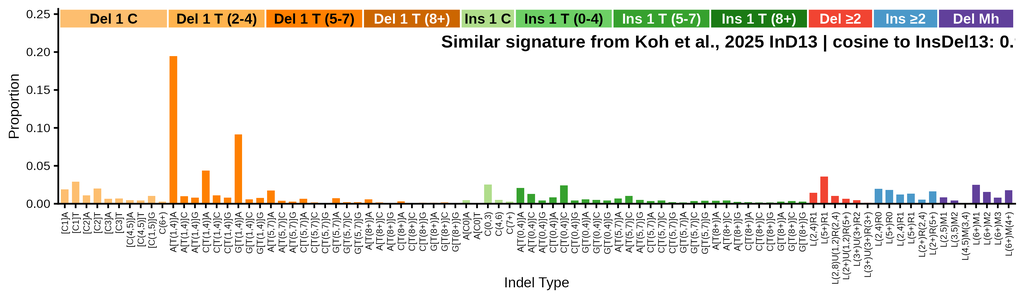

## 476-type representations corresponding to InsDel13

Extracted 476-type signature corresponding to InsDel13

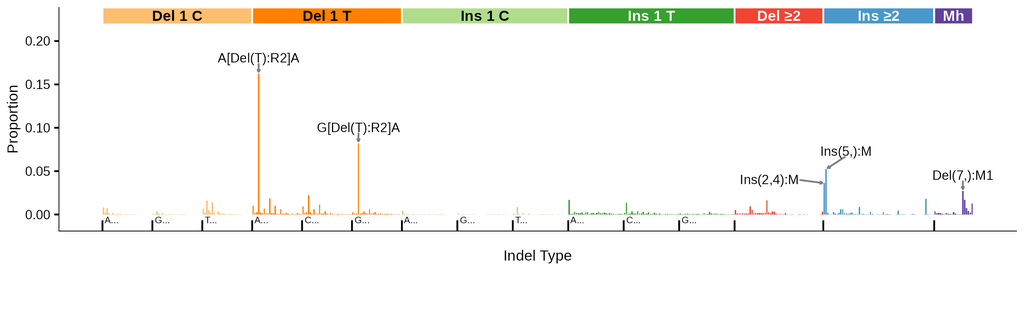

476-type spectrum of the linking tumor CPCT02060291T; cosine similarity to the extracted 476-type signature is 0.982

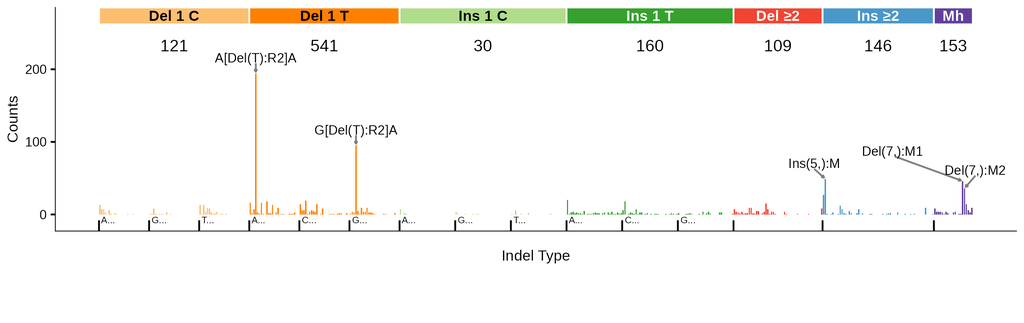

476-type spectrum of best 476-type matching tumor CPCT02050424T; cosine similarity to the extracted 476-type signature is 0.9953

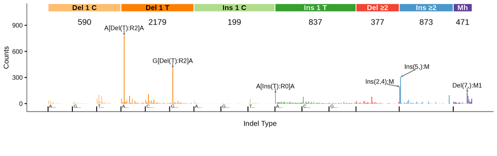

## 83-type signature corresponding to InsDel13 (C_ID13)

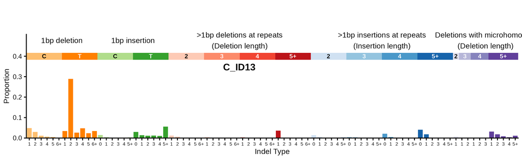

83-type signature converted from signature discovered in the 476-type spectra (using bipartite matching optimization) | cosine similarity to C_ID13: 0.996

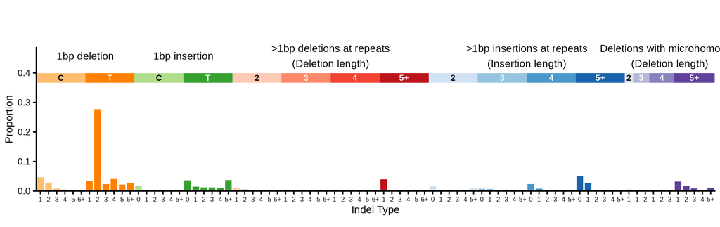

**Click to see flow diagrams: 476-type to 83-type collapse**

These Sankey diagrams show how the 476-type mutation categories are redistributed to 83-type categories using bipartite matching. We only show the diagrams for insertions or deletions of > 1 base because it is for these indels that 476-type categories map to > 1 83-type category.

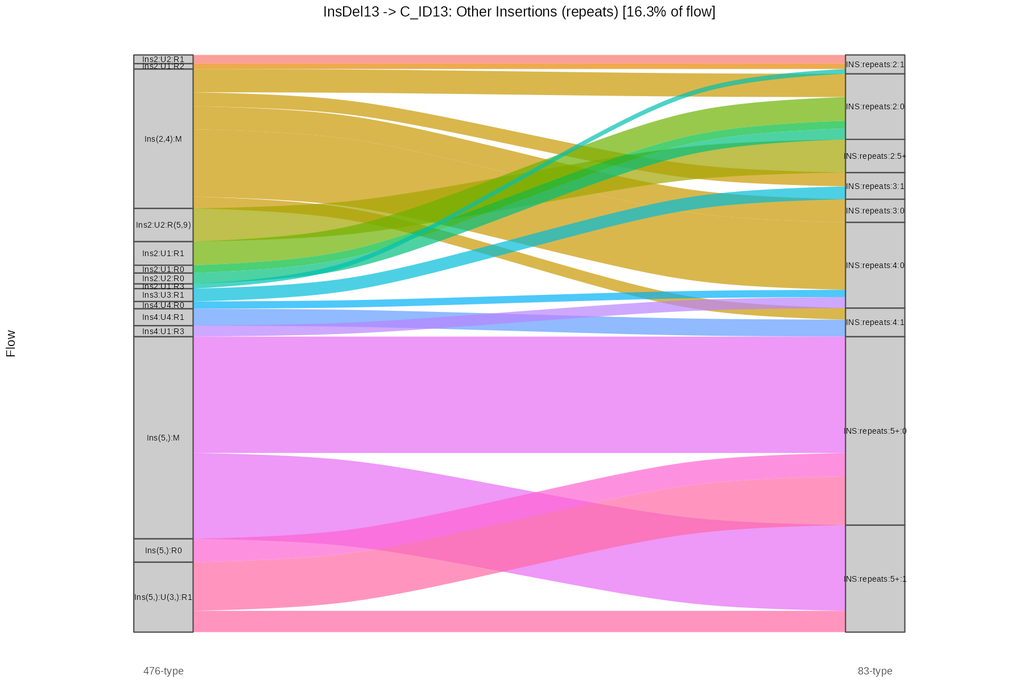

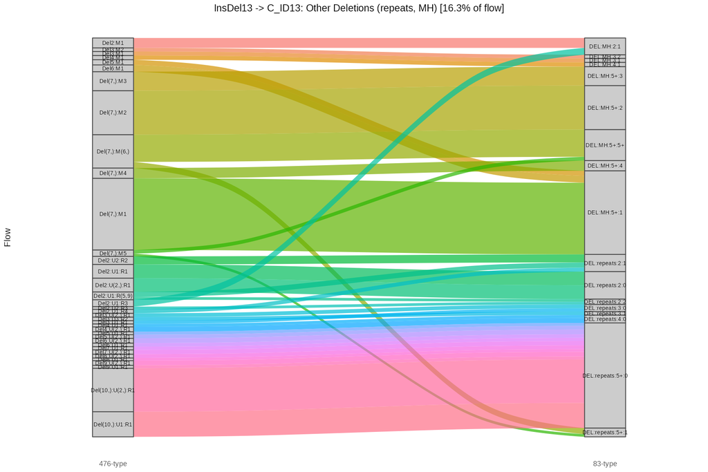

83-type spectrum of the linking tumor CPCT02060291T | cosine similarity to C_ID13: 0.9899

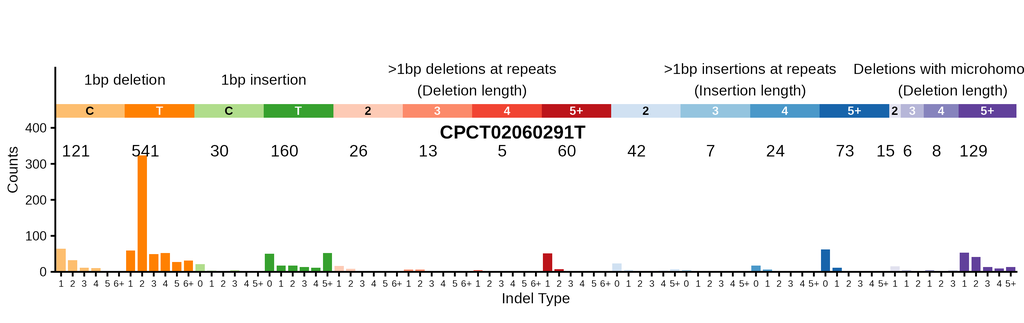

83-type spectrum of best 83-type matching tumor CPCT02050424T | cosine similarity to C_ID13: 0.9913

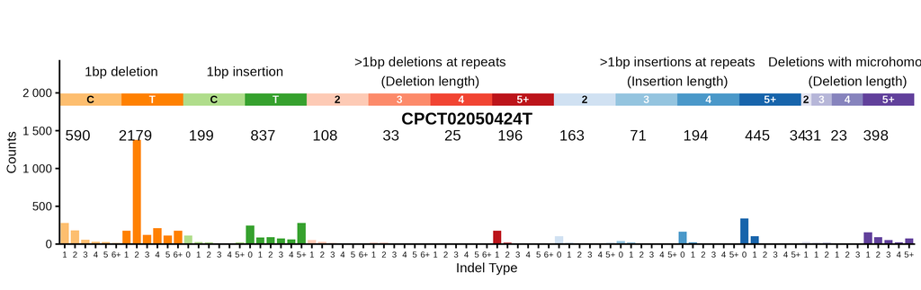

### Similar COSMIC signatures

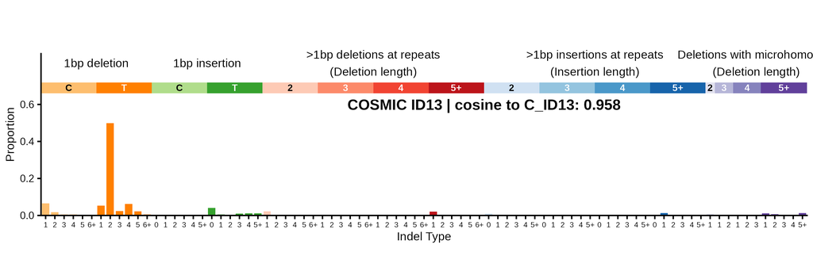

### Similar signatures from Jin et al. 2024

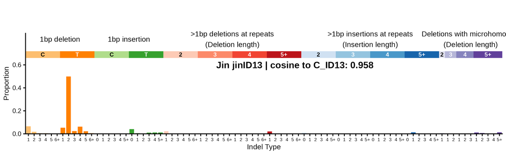